# Composition Analysis of the German National Bibliography dated 2025-03-25

# Overall summary

- data/dnb/dnb.parquet (1.37GB)- data/dnb/dnb_2.parquet (2.65GB)- data/dnb/dnb_3.parquet (1.79GB)- data/dnb/dnb_4.parquet (734MB)

## Temporal overview

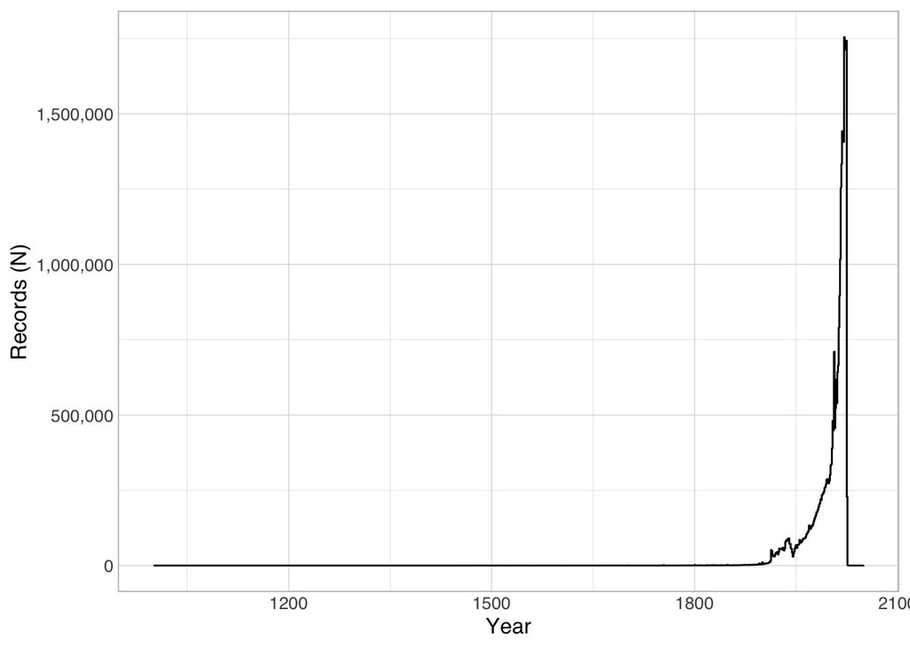

1,081,138 records do not have easily parseable dates between the years 1000 and 2050.

## Language overview

| [] | Records (N) | Proportion (%) |
| --- | --- | --- |
| ger (German) | 18498430 | 0.536029716300595 |
| eng (English) | 9549653 | 0.276720661610695 |
| \|\|\| | 5482158 | 0.158856702836675 |
| fre (French) | 181405 | 0.00525657964948969 |
| spa (Spanish; Castilian) | 112658 | 0.00326449519115906 |
| rus (Russian) | 84681 | 0.00245380458806778 |
| dut (Dutch; Flemish) | 74498 | 0.00215873140612267 |
| ita (Italian) | 61171 | 0.0017725544154733 |
| zxx (No linguistic content; Not applicable) | 57855 | 0.00167646655616563 |
| por (Portuguese) | 47468 | 0.00137548205838856 |

[output cut: 409 more lines]

# Field code usage overview

In total, 129 distinct fields are used.

Legend for the table below:

- `records`: how many records have at least one of this field
- `r_p`: the above as a percentage of all records
- `n`: the total number of appearances of this field
- `vals_per_rec`: calculated from the above, the mean number of appearances of this field per record
- `recs_with_mult_vals`: the number of records that have more than one repetition of this field

| field_code | field_description | records | r_p | n | vals_per_rec | recs_with_mult_vals |
| --- | --- | --- | --- | --- | --- | --- |
| <a name="001" href="https://www.loc.gov/marc/bibliographic/bd001.html">001</a> | Control Number | 34510083 | 1 | 34510083 | 1 | 0 |
| <a name="003" href="https://www.loc.gov/marc/bibliographic/bd003.html">003</a> | Control Number Identifier | 34510083 | 1 | 34510083 | 1 | 0 |
| <a name="005" href="https://www.loc.gov/marc/bibliographic/bd005.html">005</a> | Date and Time of Latest Transaction | 34510083 | 1 | 34510083 | 1 | 0 |
| <a name="006" href="https://www.loc.gov/marc/bibliographic/bd006.html">006</a> | Additional Material Characteristics | 14716 | 0.000426426096975774 | 16040 | 1.08997010057081 | 1323 |
| <a name="007" href="https://www.loc.gov/marc/bibliographic/bd007.html">007</a> | Physical Description | 34397193 | 0.996728782135934 | 34814392 | 1.01212886760847 | 415439 |
| <a name="008" href="https://www.loc.gov/marc/bibliographic/bd008.html">008</a> | General Information | 34510083 | 1 | 34510083 | 1 | 0 |
| <a name="010" href="https://www.loc.gov/marc/bibliographic/bd010.html">010</a> | Library of Congress Control Number | 7974 | 0.000231062904137321 | 7976 | 1.00025081514924 | 2 |
| <a name="015" href="https://www.loc.gov/marc/bibliographic/bd015.html">015</a> | National Bibliography Number | 14643922 | 0.42433749000256 | 31896527 | 2.17814100621405 | 14643922 |
| <a name="016" href="https://www.loc.gov/marc/bibliographic/bd016.html">016</a> | National Bibliographic Agency Control Number | 34510083 | 1 | 107084721 | 3.10299807160707 | 34510083 |
| <a name="020" href="https://www.loc.gov/marc/bibliographic/bd020.html">020</a> | International Standard Book Number | 11107720 | 0.321868828886908 | 36851888 | 3.31768247669189 | 8048893 |

[output cut: 119 more lines]

# Field code usage overview by subfield

In total, 774 distinct field+subfield combinations are used.

Legend for the table below:

- `records`: how many records have at least one of this field+subfield
- `r_p`: the above as a percentage of all records
- `dist_vals`: the number of different values appearing in this field+subfield
- `e_vals`: at most seven random sample values of this field+subfield
- `n`: the total number of appearances of this field+subfield
- `vals_per_rec`: calculated from the above, the mean number of appearances of this field+subfield per record
- `recs_with_mult_vals`: the number of records that have more than one repetition of this field+subfield

| subfield_code | subfield_description | records | r_p | dist_vals | e_vals | n | vals_per_rec | recs_with_mult_vals |
| --- | --- | --- | --- | --- | --- | --- | --- | --- |
| [001: Control Number](https://www.loc.gov/marc/bibliographic/bd001.html) |  |  |  |  |  |  |  |  |
| 001$ | NA | 34,510,083 | 100% | 34,510,083 | 1044123648 (1)\|135537894X (1)\|1260090663 (1)\|1067120912 (1)\|1172411867 (1)\|1190864592 (1)\|801306310 (1) | 34,510,083 | 1 | 0 |
| [003: Control Number Identifier](https://www.loc.gov/marc/bibliographic/bd003.html) |  |  |  |  |  |  |  |  |
| 003$ | NA | 34,510,083 | 100% | 1 | DE-101 (34510083) | 34,510,083 | 1 | 0 |
| [005: Date and Time of Latest Transaction](https://www.loc.gov/marc/bibliographic/bd005.html) |  |  |  |  |  |  |  |  |
| 005$ | NA | 34,510,083 | 100% | 9,961,796 | 20221130050505.0 (1)\|20210602102727.0 (1)\|20210421092803.0 (1)\|20210603064835.0 (2)\|20230807201255.0 (12)\|20231107111905.0 (1)\|20240503053309.0 (1) | 34,510,083 | 1 | 0 |
| [006: Additional Material Characteristics](https://www.loc.gov/marc/bibliographic/bd006.html) |  |  |  |  |  |  |  |  |
| 006$ | NA | 14,716 | 0.04% | 60 | sz\|\|p\|o \|\|\| 0\|\|\|\|1 (6)\|sq (2191)\|sf\|\|p\|o \|\|\| 0\|\|\|\|1 (1)\|sa\|\|p\|q \|\|\| 0\|\|\|\|1 (411)\|sz\|\|m\|q \|\|\| 0\|\|\|\|1 (402)\|su\|\|n\|q \|\|\| 0\|\|\|\|1 (1)\|si (507) | 16,040 | 1.09 | 1,323 |
| [007: Physical Description](https://www.loc.gov/marc/bibliographic/bd007.html) |  |  |  |  |  |  |  |  |
| 007$ | NA | 34,397,193 | 99.67% | 364 | hd afu000bucu (8)\|he mmc000bucu (1)\|cr\|\|uu---uuuu\| (1)\|hd ufu000uuuu (69)\|cr\|c\|\|024\|pa\|\| (6)\|hd bfu010buau (1)\|cr\|b\| mmm\|amma (1) | 34,814,392 | 1.01 | 415,439 |
| [008: General Information](https://www.loc.gov/marc/bibliographic/bd008.html) |  |  |  |  |  |  |  |  |
| 008$ | NA | 34,510,083 | 100% | 2,313,901 | 070619s1992 gw \|\|a\|\|r\|\|\|\|\|\|\|\|\|\|\|ger (1)\|120903s2007 gw \|\|\|\|\|o\|\|\|\|\|\|\|\|\|\|\|ger (1)\|100323s2009 gw \|\|\|\|\|o\|\|\|\| 00\|\|\|\|ger (1)\|230807s2024 gw u\|\|p\| \|\|\| 0\… | 34,510,083 | 1 | 0 |
| [010: Library of Congress Control Number](https://www.loc.gov/marc/bibliographic/bd010.html) |  |  |  |  |  |  |  |  |
| 010$a | LC control number | 7,974 | 0.02% | 7,950 | 2011047704 (1)\|2015045904 (1)\|2017014731 (1)\|2012040051 (1)\|2017368303 (1)\|2010031669 (1)\|2010022950 (1) | 7,976 | 1 | 2 |
| [015: National Bibliography Number](https://www.loc.gov/marc/bibliographic/bd015.html) |  |  |  |  |  |  |  |  |
| 015$2 | NA | 14,643,922 | 42.43% | 1 | dnb (14643922) | 14,643,922 | 1 | 0 |
| 015$a | National bibliography number | 14,643,922 | 42.43% | 5,071,146 | 76,H11,0415 (1)\|84,A44,0344 (1)\|88,A33,0810 (1)\|94,B25,0216 (1)\|89,B38,0698 (1)\|84,B25,0142 (1)\|96,A11,1008 (1) | 14,805,338 | 1.01 | 160,795 |
| 015$z | NA | 2,446,459 | 7.09% | 1,250,664 | 00,N31,0397 (1)\|00,N18,0722 (1)\|97,N35,0865 (1)\|85,N06,0319 (1)\|90,N37,0008 (1)\|01,N47,0085 (1)\|95,N05,0623 (1) | 2,447,267 | 1 | 770 |
| [016: National Bibliographic Agency Control Number](https://www.loc.gov/marc/bibliographic/bd016.html) |  |  |  |  |  |  |  |  |
| 016$2 | Source | 34,510,083 | 100% | 7 | DE-101 (34510083)\|UK (1715)\|ItFiC (28)\|DE-101c (555253)\|DE-600 (627732)\|DE-? (78)\|DE-Rt5 (18) | 35,694,907 | 1.03 | 1,184,791 |
| 016$Y | NA | 34,510,083 | 100% | 1 | 7 (35694907) | 35,694,907 | 1.03 | 1,184,791 |
| 016$a | Record control number | 34,510,083 | 100% | 35,536,418 | 1012324303 (1)\|2278943-1 (1)\|1287922880 (1)\|577499009 (1)\|1058445235 (1)\|1310458693 (1)\|1252387806 (1) | 35,694,907 | 1.03 | 1,184,791 |
| [020: International Standard Book Number](https://www.loc.gov/marc/bibliographic/bd020.html) |  |  |  |  |  |  |  |  |
| 020$9 | NA | 8,029,064 | 23.27% | 11,534,942 | 978-3-384-17499-4 (2)\|978-0-471-47427-2 (1)\|978-3-640-11965-3 (1)\|978-3-942514-48-4 (1)\|978-3-668-40791-6 (1)\|978-3-596-23674-9 (1)\|3-96940-856-3 (1) | 12,787,159 | 1.59 | 4,455,780 |
| 020$a | International Standard Book Number | 7,981,114 | 23.13% | 11,439,398 | 9783668434875 (1)\|9783872266019 (2)\|9783981404890 (1)\|9783638836173 (1)\|3642427987 (1)\|9783404281985 (1)\|3551714649 (1) | 12,681,166 | 1.59 | 4,431,968 |
| 020$c | Terms of availability | 8,088,417 | 23.44% | 726,258 | geb. : $ 154.00 (1)\|kart. : ca. DM 168.00, sfr 151.00, S 1226.00 (2)\|kart. : EUR 25.00 (DE), sfr 42.80 (freier Pr.) (1)\|Broschur : EUR 20.90 (DE), EUR 20.90 (DE), CHF 23.00 (freier Preis), CHF 23.0… | 10,796,137 | 1.33 | 2,492,957 |
| 020$q | NA | 224,930 | 0.65% | 25,648 | Max Planck Inst. (1)\|Stadt- und Stiftsarchiv Aschaffenburg (1)\|Industrielizenz, Einzelplatzversion (2)\|Inst. für Stadtbauwesen, Rhein.-Westfäl. Techn. Hochsch. (2)\|Version 5.0 (4)\| IKSiO PAN (1)\… | 481,433 | 2.14 | 115,428 |
| 020$z | Cancelled/invalid ISBN | 101,992 | 0.3% | 100,566 | 3554700292 (1)\|39250220301 (1)\|39377274609 (1)\|3496020571 (1)\| 9788834879948 (1)\|342506360X (1)\|8473392248 (1) | 105,993 | 1.04 | 3,790 |
| [022: International Standard Serial Number](https://www.loc.gov/marc/bibliographic/bd022.html) |  |  |  |  |  |  |  |  |
| 022$2 | NA | 65,740 | 0.19% | 1 | 6 (66804) | 66,804 | 1.02 | 856 |

[output cut: 873 more lines]